```python
import pandas as pd
import numpy as np
import matplotlib.pyplot as plt
import seaborn as sns
```

```python
pd.set_option('display.min_rows', 10000)
pd.set_option('display.max_rows', 20000)
pd.options.mode.chained_assignment = None  # default='warn'
```

```python
plt.rcParams["figure.figsize"] = (20,10)
```

# INDEX

- Loading data
  - Columns meaning
- PREPROCESSING AND ADDING ADDITIONAL FEATURES
  - Original number of events
  - Mark sessions with start or end actions before or after server_time
  - Estimate visit_total_time_sum (session_duration)
  - Common events duration estimation
  - Final events duration estimation
  - Maximum event duration
  - Mark events with durations too long
  - Event duration outliers explanation
  - Mark sessions with cyclical events with same duration
  - Mark sessions with consecutive long events
  - Combine contigous events of the same application
  - Add number of applications used on each session
  - Add number of unique applications used on each session
  - Add list of apps used in session
  - Mark users with some loggin as logged always
  - Add string categories for users
  - Calculate session duration
  - Calculate mean event duration
  - Mark sessions with one event and zero duration
  - Mark app-11 scrapers as outlier
  - Add string categories for session duration
- AUXILIAR PLOT FUNCTIONS
- FILTERED DATASETS CREATION
- PLOTS
  - Plots dataset original
  - Event durations before and after apply rules
  - Apps durations before and after apply rules
  - Applications mean/median durations after apply rules
  - Plots after apply rules
  - Plots after apply rules and remove sessions of one app

```python
import glob
path = r'C:\DRO\DCL_rawdata_files' # use your path
all_files = glob.glob(path + "/*.csv")
li = []
for filename in all_files:
    df = pd.read_csv(filename, index_col=None, header=0)
    li.append(df)
frame = pd.concat(li, axis=0, ignore_index=True)
```

# Loading data

```python
df = pd.read_csv("vaishali_cleaned_data_sep20.csv")
# object to datetime conversion
df["server_time"] = pd.to_datetime(df["server_time"],format="%Y-%m-%d %H:%M:%S.%f")
df["visit_first_action_time"] = pd.to_datetime(df["visit_first_action_time"],format="%Y-%m-%d %H:%M:%S.%f")
df["visit_last_action_time"] = pd.to_datetime(df["visit_last_action_time"],format="%Y-%m-%d %H:%M:%S.%f")
# remove old index
df.drop(columns=['Unnamed: 0'], inplace=True)
# string columns conversion
df.rename(columns= {'appname_c': 'appname_int'}, inplace=True)
df['appname_c'] = 'app-' + df['appname_int'].astype('str')
df['event_action_c'] = 'action-' + df['event_action_c'].astype('str')
```

```python
df.info(verbose=True, null_counts=True)
```

```
<class 'pandas.core.frame.DataFrame'>
RangeIndex: 3594420 entries, 0 to 3594419
Data columns (total 14 columns):
 #   Column                   Non-Null Count    Dtype
---  ------                   --------------    -----
 0   server_time              3594420 non-null  datetime64[ns]
 1   visitor_id_c             3594420 non-null  int64
 2   event_action_c           3594420 non-null  object
 3   appname_int              3594420 non-null  int64
 4   session_hk_c             3594420 non-null  int64
 5   time_spent_ref_action    3594420 non-null  int64
 6   visit_total_time         3594420 non-null  int64
 7   session_duration         3594420 non-null  int64
 8   visit_first_action_time  3594420 non-null  datetime64[ns]
 9   visit_last_action_time   3594420 non-null  datetime64[ns]
 10  step_session             3594420 non-null  int64
 11  user_logged              3594420 non-null  int64
 12  user_returning           3594420 non-null  int64
 13  appname_c                3594420 non-null  object
dtypes: datetime64[ns](3), int64(9), object(2)
memory usage: 383.9+ MB
```

```python
print(f"Number of events : {df.shape[0]}")
print(f"Number of sessions : {len(df['session_hk_c'].unique())}")
print(f"Number of users : {len(df['visitor_id_c'].unique())}")
```

```
Number of events : 3594420
Number of sessions : 488032
Number of users : 355902
```

```python
df[df["session_hk_c"]==0][["session_hk_c","visitor_id_c","appname_int","server_time","time_spent_ref_action"]].head(5)
```

|  | session_hk_c | visitor_id_c | appname_int | server_time | time_spent_ref_action |
| --- | --- | --- | --- | --- | --- |
| 0 | 0 | 77997 | 11 | 2020-09-21 12:25:57 | 2 |
| 1 | 0 | 77997 | 11 | 2020-09-21 12:26:07 | 10 |
| 2 | 0 | 77997 | 11 | 2020-09-21 12:26:09 | 2 |
| 3 | 0 | 77997 | 11 | 2020-09-21 12:27:23 | 74 |
| 4 | 0 | 77997 | 11 | 2020-09-21 12:27:25 | 2 |

### COLUMNS MEANING

- **server_time:** Server time (more reliable than session_duration)
- **visitor_id_c:** User identifier (if cookies are cleaned, it has another id)
- **event_action_c:** Actions (click, enter to some place...)
- **appname_c:** Aplication used
- **session_hk_c:** Session identifier
- **time_spent_ref_action:** Event duration (provided by matomo)
- **visit_total_time:** Visit total time (seconds) provided by matomo (probably wrong) (sum of app session_duration)
- **session_duration:** Usage total time (seconds) of an unique app during a session provided by matomo (probably wrong).It calculated by substracting visit_last_action_time and visit_first_action_time
- **visit_first_action_time:** Server time of the first action of an unique app during a session.
- **visit_last_action_time:** Server time of the last action of an unique app during a session.
- **step_session:** Record position inside its session
- **user_logged:** 0-> not logged user 1-> logged user (common user)
- **user_returning:** 0-> User that never visited the page before. 1 -> User that visited the page before

### GOOD EXAMPLES

- **session_hk_c = 0:** (81 events)
- **session_hk_c = 488029:** (4 events)
- **session_hk_c = 2:** (2 events)
- **session_hk_c = 193834:** (Possible JS error)
- **session_hk_c = 147161:** (Possible JS error) (cycle 10 min, 20 min...)
- **session_hk_c = 160801/26583:** (Possible JS error) (10 min events, app-61)
- **session_hk_c = 369135/177795:** (Possible JS error) (2 s events, app-11, very long sessions)
- **session_hk_c = 100:** (Possible session closing error)

```python
df.head(81)
```

|  | server_time | visitor_id_c | event_action_c | appname_int | session_hk_c | time_spent_ref_action | visit_total_time | session_duration | visit_first_action_time | visit_last_action_time | step_session | user_logged | user_returning | appname_c |
| --- | --- | --- | --- | --- | --- | --- | --- | --- | --- | --- | --- | --- | --- | --- |
| 0 | 2020-09-21 12:25:57 | 77997 | action-1 | 11 | 0 | 2 | 21740 | 21738 | 2020-09-21 07:10:47 | 2020-09-21 13:13:05 | 0 | 0 | 1 | app-11 |
| 1 | 2020-09-21 12:26:07 | 77997 | action-1 | 11 | 0 | 10 | 21740 | 21738 | 2020-09-21 07:10:47 | 2020-09-21 13:13:05 | 1 | 0 | 1 | app-11 |
| 2 | 2020-09-21 12:26:09 | 77997 | action-1 | 11 | 0 | 2 | 21740 | 21738 | 2020-09-21 07:10:47 | 2020-09-21 13:13:05 | 2 | 0 | 1 | app-11 |
| 3 | 2020-09-21 12:27:23 | 77997 | action-1 | 11 | 0 | 74 | 21740 | 21738 | 2020-09-21 07:10:47 | 2020-09-21 13:13:05 | 3 | 0 | 1 | app-11 |
| 4 | 2020-09-21 12:27:25 | 77997 | action-1 | 11 | 0 | 2 | 21740 | 21738 | 2020-09-21 07:10:47 | 2020-09-21 13:13:05 | 4 | 0 | 1 | app-11 |
| 5 | 2020-09-21 12:31:02 | 77997 | action-1 | 11 | 0 | 217 | 21740 | 21738 | 2020-09-21 07:10:47 | 2020-09-21 13:13:05 | 5 | 0 | 1 | app-11 |
| 6 | 2020-09-21 12:31:03 | 77997 | action-1 | 11 | 0 | 1 | 21740 | 21738 | 2020-09-21 07:10:47 | 2020-09-21 13:13:05 | 6 | 0 | 1 | app-11 |
| 7 | 2020-09-21 12:31:11 | 77997 | action-1 | 11 | 0 | 8 | 21740 | 21738 | 2020-09-21 07:10:47 | 2020-09-21 13:13:05 | 7 | 0 | 1 | app-11 |
| 8 | 2020-09-21 12:31:13 | 77997 | action-1 | 11 | 0 | 2 | 21740 | 21738 | 2020-09-21 07:10:47 | 2020-09-21 13:13:05 | 8 | 0 | 1 | app-11 |
| 9 | 2020-09-21 12:31:21 | 77997 | action-1 | 11 | 0 | 8 | 21740 | 21738 | 2020-09-21 07:10:47 | 2020-09-21 13:13:05 | 9 | 0 | 1 | app-11 |
| 10 | 2020-09-21 12:31:23 | 77997 | action-1 | 11 | 0 | 2 | 21740 | 21738 | 2020-09-21 07:10:47 | 2020-09-21 13:13:05 | 10 | 0 | 1 | app-11 |
| 11 | 2020-09-21 12:31:46 | 77997 | action-1 | 11 | 0 | 23 | 21740 | 21738 | 2020-09-21 07:10:47 | 2020-09-21 13:13:05 | 11 | 0 | 1 | app-11 |
| 12 | 2020-09-21 12:31:51 | 77997 | action-1 | 11 | 0 | 5 | 21740 | 21738 | 2020-09-21 07:10:47 | 2020-09-21 13:13:05 | 12 | 0 | 1 | app-11 |
| 13 | 2020-09-21 12:32:51 | 77997 | action-1 | 11 | 0 | 60 | 21740 | 21738 | 2020-09-21 07:10:47 | 2020-09-21 13:13:05 | 13 | 0 | 1 | app-11 |
| 14 | 2020-09-21 12:32:53 | 77997 | action-1 | 11 | 0 | 2 | 21740 | 21738 | 2020-09-21 07:10:47 | 2020-09-21 13:13:05 | 14 | 0 | 1 | app-11 |
| 15 | 2020-09-21 12:32:59 | 77997 | action-1 | 11 | 0 | 6 | 21740 | 21738 | 2020-09-21 07:10:47 | 2020-09-21 13:13:05 | 15 | 0 | 1 | app-11 |
| 16 | 2020-09-21 12:33:01 | 77997 | action-1 | 11 | 0 | 2 | 21740 | 21738 | 2020-09-21 07:10:47 | 2020-09-21 13:13:05 | 16 | 0 | 1 | app-11 |
| 17 | 2020-09-21 12:33:31 | 77997 | action-1 | 11 | 0 | 30 | 21740 | 21738 | 2020-09-21 07:10:47 | 2020-09-21 13:13:05 | 17 | 0 | 1 | app-11 |
| 18 | 2020-09-21 12:33:33 | 77997 | action-1 | 11 | 0 | 2 | 21740 | 21738 | 2020-09-21 07:10:47 | 2020-09-21 13:13:05 | 18 | 0 | 1 | app-11 |
| 19 | 2020-09-21 12:33:53 | 77997 | action-1 | 11 | 0 | 20 | 21740 | 21738 | 2020-09-21 07:10:47 | 2020-09-21 13:13:05 | 19 | 0 | 1 | app-11 |
| 20 | 2020-09-21 12:33:55 | 77997 | action-1 | 11 | 0 | 2 | 21740 | 21738 | 2020-09-21 07:10:47 | 2020-09-21 13:13:05 | 20 | 0 | 1 | app-11 |
| 21 | 2020-09-21 12:34:10 | 77997 | action-1 | 11 | 0 | 15 | 21740 | 21738 | 2020-09-21 07:10:47 | 2020-09-21 13:13:05 | 21 | 0 | 1 | app-11 |
| 22 | 2020-09-21 12:34:12 | 77997 | action-1 | 11 | 0 | 2 | 21740 | 21738 | 2020-09-21 07:10:47 | 2020-09-21 13:13:05 | 22 | 0 | 1 | app-11 |
| 23 | 2020-09-21 12:34:45 | 77997 | action-1 | 11 | 0 | 33 | 21740 | 21738 | 2020-09-21 07:10:47 | 2020-09-21 13:13:05 | 23 | 0 | 1 | app-11 |
| 24 | 2020-09-21 12:34:47 | 77997 | action-1 | 11 | 0 | 2 | 21740 | 21738 | 2020-09-21 07:10:47 | 2020-09-21 13:13:05 | 24 | 0 | 1 | app-11 |
| 25 | 2020-09-21 12:34:56 | 77997 | action-1 | 11 | 0 | 9 | 21740 | 21738 | 2020-09-21 07:10:47 | 2020-09-21 13:13:05 | 25 | 0 | 1 | app-11 |
| 26 | 2020-09-21 12:34:58 | 77997 | action-1 | 11 | 0 | 2 | 21740 | 21738 | 2020-09-21 07:10:47 | 2020-09-21 13:13:05 | 26 | 0 | 1 | app-11 |
| 27 | 2020-09-21 12:35:44 | 77997 | action-1 | 11 | 0 | 46 | 21740 | 21738 | 2020-09-21 07:10:47 | 2020-09-21 13:13:05 | 27 | 0 | 1 | app-11 |
| 28 | 2020-09-21 12:35:46 | 77997 | action-1 | 11 | 0 | 2 | 21740 | 21738 | 2020-09-21 07:10:47 | 2020-09-21 13:13:05 | 28 | 0 | 1 | app-11 |
| 29 | 2020-09-21 12:36:16 | 77997 | action-1 | 11 | 0 | 30 | 21740 | 21738 | 2020-09-21 07:10:47 | 2020-09-21 13:13:05 | 29 | 0 | 1 | app-11 |

[output cut: 51 more lines]

```python
df["server_time"].max()
```

```
Timestamp('2020-09-30 23:59:54')
```

# PREPROCESSING AND ADDING ADDITIONAL FEATURES

In this section, multiple features were added:

- **num_events:** Number of events of the session (before combine contigous apps)
- **event_duration:** Duration of a event (s) (before combine contigous apps, after this disppears)
- **calculated_app_duration:** Time that user remains in the same app in seconds. This time can be 0 in the last app of a session if only has an event.
- **app_num_events:** Number of events that were combined in an app.
- **num_apps:** Number of applications visited during a session.
- **num_apps_without_wipo_account:**Number of applications visited during a session without count wipo account
- **num_unique_apps:** Number of applications visited during a session.
- **used_app_list:** List of applications visited during a session.
- **user_logged_treated:** user_logged modified (being set as 1 for all users who ever logged in)
- **user_log_info:** Description string with logging data: ["logged", "not logged"]
- **user_returning_info:** Description string with returning data:["returning", "not returning"]
- **user_description:** Description string with logging data and returning data
- **calculated_session_duration:** Session duration calculated based on event's server time.
- **session_duration_range:** String with session duration inside the defined ranges.
- **mean_event_duration:**Session mean event duration
- **app_mean_event_duration:**App mean event duration
- **visit_total_time_sum:** Session duration (with provided feature)

Outlier features:

## Original number of events

```python
df["num_events"] = df.groupby("session_hk_c")["session_hk_c"].transform('count')
```

## Mark sessions with start or end actions before or after server_time

```python
bad_end_sessions = df[(df["step_session"]==df["num_events"]-1)&\
                ((df["visit_last_action_time"]-df["server_time"]).dt.total_seconds()>60)]\
                    ["session_hk_c"]

bad_start_sessions = df[(df["step_session"]==0)&((df["server_time"]-df["visit_first_action_time"]).dt.total_seconds()>60)]\
                    ["session_hk_c"]
```

```python
df["visit_actions_outlier"] = 0
df["visit_actions_outlier"][(df["session_hk_c"].isin(bad_end_sessions))|(df["session_hk_c"].isin(bad_start_sessions))] = 1
```

```python
print("Sessions marked as outliers because action time not correct: {}/{}".format(
        df[(df["visit_actions_outlier"]==1)&(df["step_session"]==0)].shape[0], len(df['session_hk_c'].unique())
))
```

```
Sessions marked as outliers because action time not correct: 8476/488032
```

## Estimate visit_total_time_sum (session_duration)

```python
visit_total_time_df = df[["session_hk_c","appname_c","visit_total_time"]].drop_duplicates()\
                            .groupby("session_hk_c")[["visit_total_time"]].agg("sum")
visit_total_time_df.rename(columns= {'visit_total_time': 'visit_total_time_sum'}, inplace=True)
```

```python
df = df.merge(visit_total_time_df, how="left", left_on="session_hk_c", right_index=True)
```

## Common events duration estimation

```python
df['elapsedtimedf1'] = df.groupby("session_hk_c")["server_time"].diff().dt.total_seconds().fillna(0)
df['event_duration'] = df.groupby('session_hk_c')['elapsedtimedf1'].shift(-1).fillna(0)
df.drop(columns=["elapsedtimedf1"],inplace=True)
```

```python
df[df["session_hk_c"]==177795][["session_hk_c","visitor_id_c","appname_int","server_time","event_duration"]].shape
```

```
(18256, 5)
```

## Final events duration estimation

```python
df = df.sort_values(["session_hk_c","server_time"])
```

```python
df_shifted= df[["session_hk_c","server_time"]].shift(-1)
condition_results = df["session_hk_c"] != df_shifted["session_hk_c"]
```

```python
df["event_duration"][condition_results]  = (df[condition_results]["visit_last_action_time"] - df[condition_results]["server_time"]).dt.total_seconds()
```

```python
del df_shifted
```

## Maximum event duration

```python
df["max_event_duration"] = df.groupby("session_hk_c")["event_duration"].transform("max")
```

## Mark events with durations too long

```python
# sessions with some event with a duration > 30 mins
sess_dur_outlier = df.loc[df["event_duration"]>(60*25),'session_hk_c']
df["event_duration_outlier"] = 0
df["event_duration_outlier"][df["session_hk_c"].isin(sess_dur_outlier)] = 1
```

```python
num_sessions_dropped = df[["session_hk_c","event_duration_outlier"]][df["event_duration_outlier"]==1].drop_duplicates().shape[0]
print(f"Sessions marked as outliers because event duration: {num_sessions_dropped}/{len(df['session_hk_c'].unique())}")
```

```
Sessions marked as outliers because event duration: 17740/488032
```

## Event duration outliers explanation

There are events with very long durations.  
This is caused because the session contains events with server times very different.  
As we can see in the example, in this cases, the variables visit_last_action_time let us know that the user is inactive.

```python
df_events = df.copy()
df_events["next_event_server_time"]= df_events.groupby("session_hk_c")["server_time"].shift(-1)
```

```python
df_events[["session_hk_c","server_time","visit_first_action_time","visit_last_action_time","next_event_server_time","event_duration"]]\
            [df_events["event_duration"]>10000].head(5)
```

|  | session_hk_c | server_time | visit_first_action_time | visit_last_action_time | next_event_server_time | event_duration |
| --- | --- | --- | --- | --- | --- | --- |
| 834 | 100 | 2020-09-02 07:42:53 | 2020-09-02 07:42:53 | 2020-09-02 07:42:54 | 2020-09-03 07:46:14 | 86601.0 |
| 835 | 100 | 2020-09-03 07:46:14 | 2020-09-03 07:46:14 | 2020-09-03 07:46:14 | 2020-09-04 07:13:17 | 84423.0 |
| 2734 | 405 | 2020-09-10 07:39:02 | 2020-09-10 07:38:30 | 2020-09-10 07:39:02 | 2020-09-17 11:58:50 | 620388.0 |
| 2736 | 405 | 2020-09-17 11:59:57 | 2020-09-17 11:58:50 | 2020-09-17 11:59:57 | 2020-09-22 09:24:20 | 422663.0 |
| 2737 | 405 | 2020-09-22 09:24:20 | 2020-09-22 09:24:20 | 2020-09-22 09:24:21 | 2020-09-25 09:11:21 | 258421.0 |

## Mark sessions with cyclical events with same duration

```python
aux = pd.DataFrame()
aux["session_hk_c"] = df["session_hk_c"]
aux["event_duration"] = df["event_duration"]


aux["event_duration_1"] = aux.groupby("session_hk_c")["event_duration"].shift(-1)
aux["event_duration_2"] = aux.groupby("session_hk_c")["event_duration"].shift(-2)
aux["event_duration_3"] = aux.groupby("session_hk_c")["event_duration"].shift(-3)
aux["event_duration_4"] = aux.groupby("session_hk_c")["event_duration"].shift(-4)
aux["event_duration_5"] = aux.groupby("session_hk_c")["event_duration"].shift(-5)
```

```python
seconds_diff = 10
condition_results = (
                        (np.absolute(aux["event_duration"]-aux["event_duration_2"])<seconds_diff)&\
                        (np.absolute(aux["event_duration"]-aux["event_duration_4"])<seconds_diff)&\
                        (np.absolute(aux["event_duration_1"]-aux["event_duration_3"])<seconds_diff)&\
                        (np.absolute(aux["event_duration_1"]-aux["event_duration_5"])<seconds_diff)&\
                        (~aux["event_duration"].isna())&(~aux["event_duration_1"].isna())\
                        &(aux["event_duration"]>15) & (aux["event_duration_1"]>15)
                    )
aux["is_cycle"] = condition_results
outlier_sessions = aux[condition_results]["session_hk_c"].unique()
```

```python
df["cyclic_event_outlier"] = 0
df["cyclic_event_outlier"][df["session_hk_c"].isin(outlier_sessions)] = 1
```

```python
df_events["cyclic_event_outlier"] = df["cyclic_event_outlier"]
del aux
```

```python
print(f"Sessions marked as outliers because cyclic event: {len(outlier_sessions)}/{len(df['session_hk_c'].unique())}")
```

```
Sessions marked as outliers because cyclic event: 2607/488032
```

## Mark sessions with consecutive long events

```python
aux = pd.DataFrame()
aux["session_hk_c"] = df["session_hk_c"]
aux["event_duration_min"] = df["event_duration"]/60

aux["event_duration_min_1"] = aux.groupby("session_hk_c")["event_duration_min"].shift(-1)
aux["event_duration_min_2"] = aux.groupby("session_hk_c")["event_duration_min"].shift(-2)
aux["event_duration_min_3"] = aux.groupby("session_hk_c")["event_duration_min"].shift(-3)
aux["event_duration_min_4"] = aux.groupby("session_hk_c")["event_duration_min"].shift(-4)
aux["event_duration_min_5"] = aux.groupby("session_hk_c")["event_duration_min"].shift(-5)
```

```python
aux
```

|  | session_hk_c | event_duration_min | event_duration_min_1 | event_duration_min_2 | event_duration_min_3 | event_duration_min_4 | event_duration_min_5 |
| --- | --- | --- | --- | --- | --- | --- | --- |
| 0 | 0 | 0.166667 | 0.033333 | 1.233333 | 0.033333 | 3.616667 | 0.016667 |
| 1 | 0 | 0.033333 | 1.233333 | 0.033333 | 3.616667 | 0.016667 | 0.133333 |
| 2 | 0 | 1.233333 | 0.033333 | 3.616667 | 0.016667 | 0.133333 | 0.033333 |
| 3 | 0 | 0.033333 | 3.616667 | 0.016667 | 0.133333 | 0.033333 | 0.133333 |
| 4 | 0 | 3.616667 | 0.016667 | 0.133333 | 0.033333 | 0.133333 | 0.033333 |
| 5 | 0 | 0.016667 | 0.133333 | 0.033333 | 0.133333 | 0.033333 | 0.383333 |
| 6 | 0 | 0.133333 | 0.033333 | 0.133333 | 0.033333 | 0.383333 | 0.083333 |
| 7 | 0 | 0.033333 | 0.133333 | 0.033333 | 0.383333 | 0.083333 | 1.000000 |
| 8 | 0 | 0.133333 | 0.033333 | 0.383333 | 0.083333 | 1.000000 | 0.033333 |
| 9 | 0 | 0.033333 | 0.383333 | 0.083333 | 1.000000 | 0.033333 | 0.100000 |
| 10 | 0 | 0.383333 | 0.083333 | 1.000000 | 0.033333 | 0.100000 | 0.033333 |
| 11 | 0 | 0.083333 | 1.000000 | 0.033333 | 0.100000 | 0.033333 | 0.500000 |
| 12 | 0 | 1.000000 | 0.033333 | 0.100000 | 0.033333 | 0.500000 | 0.033333 |
| 13 | 0 | 0.033333 | 0.100000 | 0.033333 | 0.500000 | 0.033333 | 0.333333 |
| 14 | 0 | 0.100000 | 0.033333 | 0.500000 | 0.033333 | 0.333333 | 0.033333 |
| 15 | 0 | 0.033333 | 0.500000 | 0.033333 | 0.333333 | 0.033333 | 0.250000 |
| 16 | 0 | 0.500000 | 0.033333 | 0.333333 | 0.033333 | 0.250000 | 0.033333 |
| 17 | 0 | 0.033333 | 0.333333 | 0.033333 | 0.250000 | 0.033333 | 0.550000 |
| 18 | 0 | 0.333333 | 0.033333 | 0.250000 | 0.033333 | 0.550000 | 0.033333 |
| 19 | 0 | 0.033333 | 0.250000 | 0.033333 | 0.550000 | 0.033333 | 0.150000 |
| 20 | 0 | 0.250000 | 0.033333 | 0.550000 | 0.033333 | 0.150000 | 0.033333 |
| 21 | 0 | 0.033333 | 0.550000 | 0.033333 | 0.150000 | 0.033333 | 0.766667 |
| 22 | 0 | 0.550000 | 0.033333 | 0.150000 | 0.033333 | 0.766667 | 0.033333 |
| 23 | 0 | 0.033333 | 0.150000 | 0.033333 | 0.766667 | 0.033333 | 0.500000 |
| 24 | 0 | 0.150000 | 0.033333 | 0.766667 | 0.033333 | 0.500000 | 0.033333 |
| 25 | 0 | 0.033333 | 0.766667 | 0.033333 | 0.500000 | 0.033333 | 0.583333 |
| 26 | 0 | 0.766667 | 0.033333 | 0.500000 | 0.033333 | 0.583333 | 0.066667 |
| 27 | 0 | 0.033333 | 0.500000 | 0.033333 | 0.583333 | 0.066667 | 0.250000 |
| 28 | 0 | 0.500000 | 0.033333 | 0.583333 | 0.066667 | 0.250000 | 0.033333 |
| 29 | 0 | 0.033333 | 0.583333 | 0.066667 | 0.250000 | 0.033333 | 0.150000 |

[output cut: 9971 more lines]

3594420 rows × 7 columns

```python
max_mins = 10
condition_results = (
                        (aux["event_duration_min"]>max_mins)&\
                        (aux["event_duration_min_1"]>max_mins)&\
                        (aux["event_duration_min_2"]>max_mins)&\
                        (aux["event_duration_min_3"]>max_mins)&\
                        (aux["event_duration_min_4"]>max_mins)&\
                        (aux["event_duration_min_5"]>max_mins)
                    )
aux["long_consecutives_outlier"] = condition_results
outlier_sessions = aux[condition_results]["session_hk_c"].unique()
```

```python
df["long_consecutives_outlier"] = 0
df["long_consecutives_outlier"][df["session_hk_c"].isin(outlier_sessions)] = 1
```

```python
df_events["long_consecutives_outlier"] = df["long_consecutives_outlier"]
del aux
```

```python
print(f"Sessions marked as outliers because long consecutive events: {len(outlier_sessions)}/{len(df['session_hk_c'].unique())}")
```

```
Sessions marked as outliers because long consecutive events: 648/488032
```

## Combine contigous events of the same application

```python
df_shifted= df[["session_hk_c","appname_c"]].shift() #TODO check
condition_results = (df["session_hk_c"] != df_shifted["session_hk_c"]) | (df["appname_c"] != df_shifted["appname_c"])
df["global_action_id"] = (condition_results).cumsum()
```

```python
agg_dict = {x: "first" for x in df.columns}
agg_dict.update({
    "time_spent_ref_action": "sum",
    "event_duration": "sum",
    "app_num_events": "count"
})
df["app_num_events"] = 0
df = df.groupby("global_action_id",as_index=False).agg(agg_dict)
df.rename(columns= {'event_duration': 'calculated_app_duration'}, inplace=True)
```

```python
df.drop(columns=["global_action_id"],inplace=True)
```

## Add number of applications used on each session

```python
df["num_apps"] = df.groupby("session_hk_c")["session_hk_c"].transform('count')
df["num_apps_without_wipo_account"] = df[df["appname_c"]!="app-48"].groupby("session_hk_c")["session_hk_c"].transform('count')
```

## Add number of unique applications used on each session

```python
df["num_unique_apps"] =df.groupby("session_hk_c")["appname_c"].agg('nunique')
```

## Add list of apps used in session

```python
aux = pd.DataFrame()
aux["used_app_list"] =df.groupby("session_hk_c")["appname_c"].agg(lambda x : '|'.join(x))
df = df.merge(aux, how="left", left_on="session_hk_c", right_index=True)
```

## Mark users with some loggin as logged always

```python
user_state_change_df = df[["visitor_id_c","user_logged"]]\
                            .groupby("visitor_id_c")\
                            .agg(lambda x: 1 if 1 in set(x) else 0)

user_state_change_df.rename(columns= {'user_logged': 'user_logged_treated'}, inplace=True)

df = df.merge(user_state_change_df, how="left", left_on="visitor_id_c", right_index=True)
```

## Add string categories for users

```python
conds = [(df['user_logged_treated'] == 1)]
actions = ['logged']
df['user_log_info'] = np.select(conds,actions,default='not logged')

conds = [(df['user_returning'] == 1)]
actions = ['returning']
df["user_returning_info"] = np.select(conds,actions,default='not returning')

df["user_description"] = df['user_log_info'] + " " + df["user_returning_info"]
```

## Calculate session duration

```python
df["calculated_session_duration"] =df.groupby("session_hk_c")["calculated_app_duration"].transform('sum')
```

## Calculate mean event duration

```python
df["mean_event_duration"] = df["calculated_session_duration"] / df["num_events"]
df["app_mean_event_duration"] =  df["calculated_app_duration"] / df["app_num_events"]
```

## Mark sessions with one event and zero duration

```python
conds = [(df["calculated_session_duration"]<1)&(df["num_events"]==1)]
actions = [1]
df['one_event_outlier'] = np.select(conds,actions,default=0)
```

```python
print(f"Sessions marked as outliers because long consecutive events: {df['one_event_outlier'].sum()}/{len(df['session_hk_c'].unique())}")
```

```
Sessions marked as outliers because long consecutive events: 53738/488032
```

# MARK app-11 scrapers as outliers

```python
conds = [(df["used_app_list"]=="app-11")&(df["num_events"]>20) & ((df["calculated_session_duration"]/df["num_events"])<10)]
actions = [1]
df['scrapper_outlier'] = np.select(conds,actions,default=0)
```

```python
outlier_sessions = df[['session_hk_c','scrapper_outlier']][df['scrapper_outlier']==1].drop_duplicates().shape[0]
print(f"Sessions marked as outliers because scrappe app-11: {outlier_sessions}/{len(df['session_hk_c'].unique())}")
```

```
Sessions marked as outliers because scrappe app-11: 1205/488032
```

## Add string categories for session duration

```python
conds = [df['calculated_session_duration'].between(0, 5),
         df['calculated_session_duration'].between(5, 15),
            df['calculated_session_duration'].between(15, 30),
            df['calculated_session_duration'].between(30, 45),
            df['calculated_session_duration'].between(45, 60),
            df['calculated_session_duration'].between(60, 120),
            df['calculated_session_duration'].between(120, 300),
           df['calculated_session_duration'].between(300, 600),
            df['calculated_session_duration'].between(600, 1500)]
actions = ["<5 s","5-15 s", "15-30 s", "30-45 s", "45-60 s", "1-2 m", "2-5 m", "5-10 m", "10-30 m"]
df['session_duration_range'] = np.select(conds, actions, default="+30 m")
#IMPORTANT: this variable is used to plot
duration_ranges = actions + ["+30 m"]
```

# AUXILIAR PLOT FUNCTIONS

```python
def get_top_data(labels, data, top_n, add_others=False,sort=False):
    top_n_is_full = top_n >= len(data)
    labels,data = labels[:top_n],data[:top_n]
    if add_others and not top_n_is_full:
        labels = np.append(labels,["others"])
        data = np.append(data,[1 - sum(data)])

    if sort:
        return pd.Series(data, index =labels).sort_values(ascending=False)
    else:
        return pd.Series(data, index =labels)
```

```python
def plot_distribution(labels,data,title,xlabel="",top_n_pie=4,top_n_hist=12,pie_legend=False,autopct=None,bar_annot_extra=0.01):

    s = get_top_data(labels, data, top_n_pie, add_others=True,sort=True)

    fig, ax = plt.subplots(nrows=1, ncols=2)

    if pie_legend:
        ax[0].pie(s.values, labels=s.index, autopct=autopct,shadow=True, startangle=90,labeldistance=None)
        ax[0].legend(fontsize=14)
    else:
        ax[0].pie(s.values, labels=s.index, autopct=autopct,shadow=True, startangle=90)

    ax[0].axis('equal')
    ax[0].set_title(title,fontsize=16)



    s = get_top_data(labels, data, top_n_hist, add_others=False)
    ax[1].bar(s.index, s.values)
    ax[1].set_xticks(s.index)
    ax[1].set_xticklabels([str(x).replace("logged","logged\n") for x in s.index])
    ax[1].set_title(title,fontsize=16)
    ax[1].set_xlabel(xlabel,fontsize=16)

    for p in ax[1].patches:
        width = p.get_width()
        height = p.get_height()
        x, y = p.get_xy()
        ax[1].annotate(f'{round(height*100,2)}%', (x + width/2, y + height+bar_annot_extra), ha='center',fontsize=14)


    plt.show()
```

```python
def sort_serie_with_duration_ranges(s):
    labels,data = [],[]
    for x in duration_ranges:
        labels.append(x)
        data.append(s[x])
    return labels,data
```

# FILTERED DATASETS CREATION

```python
min_num_app= 1

filtered_df_events = df_events[(df_events["event_duration_outlier"]==0)&(df_events["cyclic_event_outlier"]==0)&\
                        (df_events["long_consecutives_outlier"]==0)&(df['scrapper_outlier']==0)&\
                        (df["one_event_outlier"]==0)&(df["num_apps"]>=min_num_app)&(df["visit_actions_outlier"]==0)]


filtered_df = df[(df["event_duration_outlier"]==0)&(df["cyclic_event_outlier"]==0)&\
             (df["long_consecutives_outlier"]==0)&(df['scrapper_outlier']==0)&\
             (df["one_event_outlier"]==0)&(df["num_apps"]>=min_num_app)&(df["visit_actions_outlier"]==0)]
```

```python
min_num_app_2= 2

filtered_df_events_2 = df_events[(df_events["event_duration_outlier"]==0)&(df_events["cyclic_event_outlier"]==0)&\
                        (df_events["long_consecutives_outlier"]==0)&(df['scrapper_outlier']==0)&\
                        (df["one_event_outlier"]==0)&(df["num_apps"]>=min_num_app_2)&(df["visit_actions_outlier"]==0)]


filtered_df_2 = df[(df["event_duration_outlier"]==0)&(df["cyclic_event_outlier"]==0)&\
             (df["long_consecutives_outlier"]==0)&(df['scrapper_outlier']==0)&\
             (df["one_event_outlier"]==0)&(df["num_apps"]>=min_num_app_2)&(df["visit_actions_outlier"]==0)]
```

# PLOTS

## Original dataset plots

### Users distribution

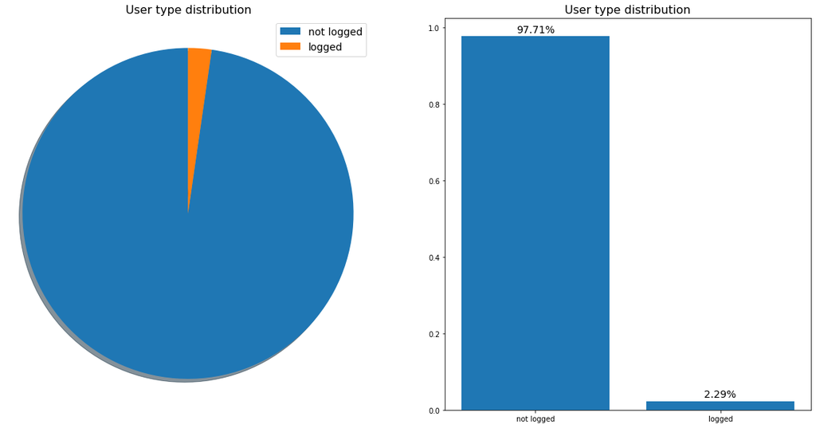

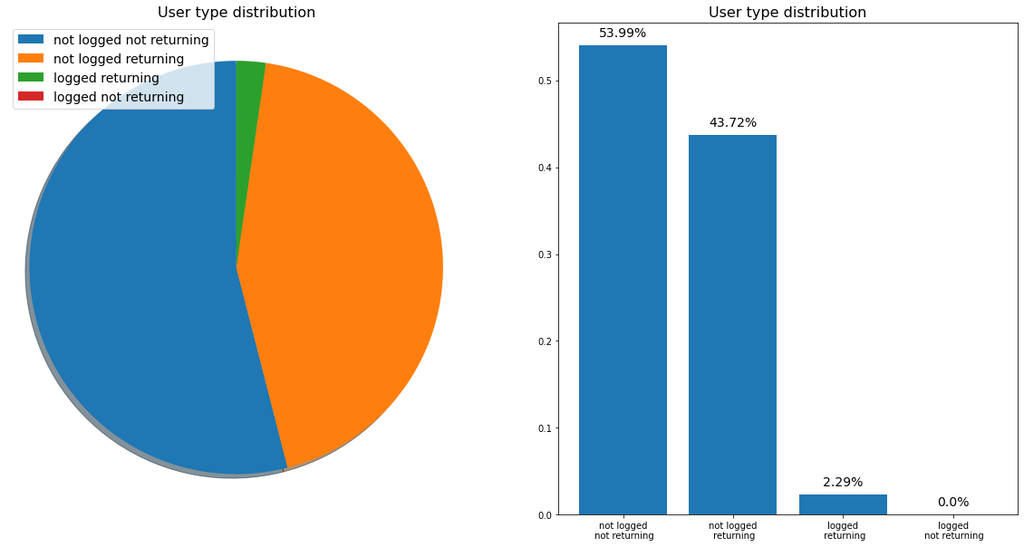

```python
user_type_dis = df[["visitor_id_c","user_log_info"]].drop_duplicates()["user_log_info"].value_counts(normalize=True)
labels,data = user_type_dis.index, user_type_dis.values
plot_distribution(labels,data,"User type distribution",top_n_pie=3, top_n_hist=3,xlabel="",pie_legend=True)


user_type_dis = df[["visitor_id_c","user_description"]].drop_duplicates()["user_description"].value_counts(normalize=True)
labels,data = user_type_dis.index, user_type_dis.values
plot_distribution(labels,data,"User type distribution",top_n_pie=8, top_n_hist=5,xlabel="",pie_legend=True)
```

# Session distribution by users

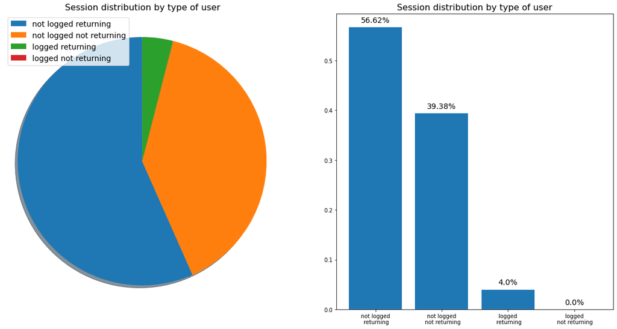

```python
user_type_dis = df[["session_hk_c","visitor_id_c","user_description"]].drop_duplicates()\
                ["user_description"].value_counts(normalize=True)
labels,data = user_type_dis.index, user_type_dis.values
plot_distribution(labels,data,"Session distribution by type of user",top_n_pie=8, top_n_hist=5,xlabel="",pie_legend=True)
```

# Number of sessions by user

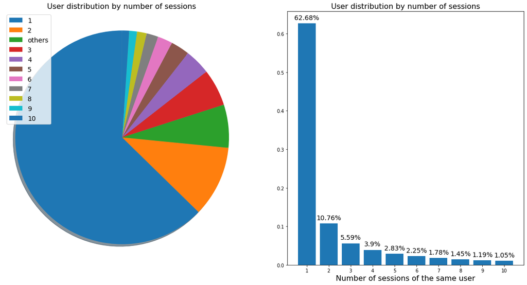

```python
user_type_dis = df[["session_hk_c","visitor_id_c","user_description"]].drop_duplicates()\
                .groupby("visitor_id_c")["visitor_id_c"].transform("count").value_counts(normalize=True)
labels,data = user_type_dis.index, user_type_dis.values
plot_distribution(labels,data,"User distribution by number of sessions",top_n_pie=10, top_n_hist=10,xlabel="Number of sessions of the same user",pie_legend=True)
```

# Session distribution by apps

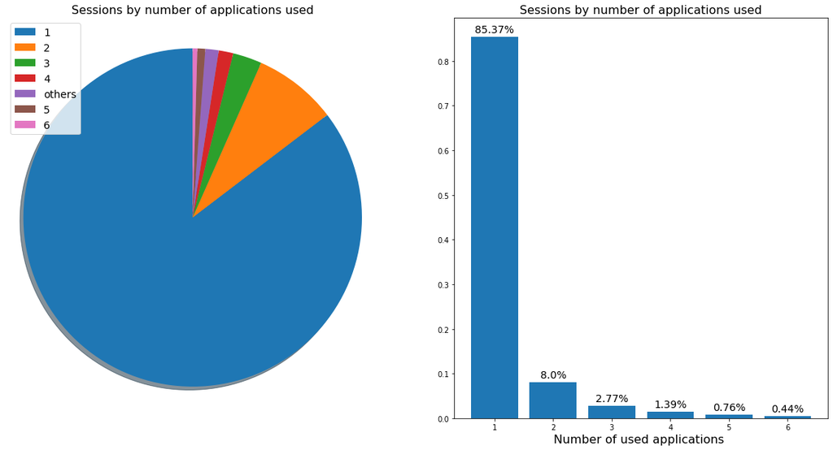

```python
ses_dur_dis = df[["session_hk_c","num_apps"]].drop_duplicates()["num_apps"]\
                    .value_counts(normalize=True)
labels,data = ses_dur_dis.index, ses_dur_dis.values
plot_distribution(labels,data,"Sessions by number of applications used",top_n_pie=6, top_n_hist=6,xlabel="Number of used applications ",pie_legend=True)
```

# Session distribution by apps depending on the type of user

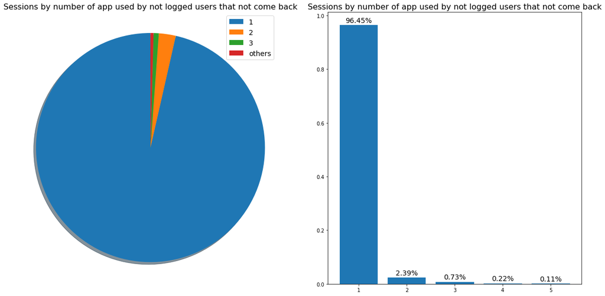

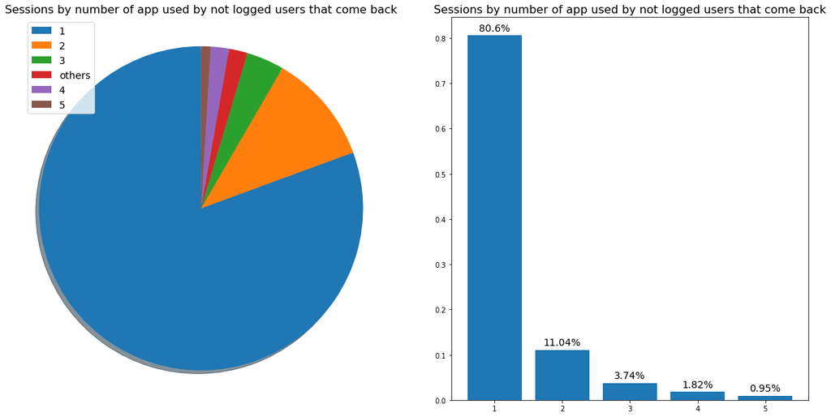

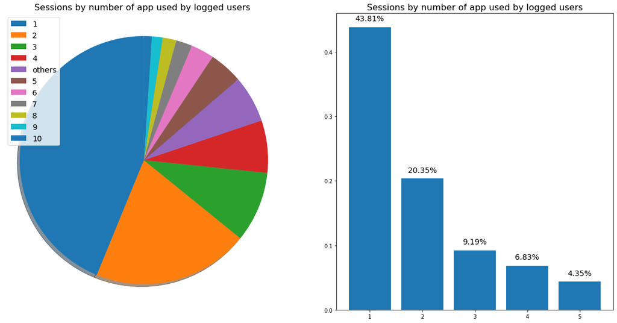

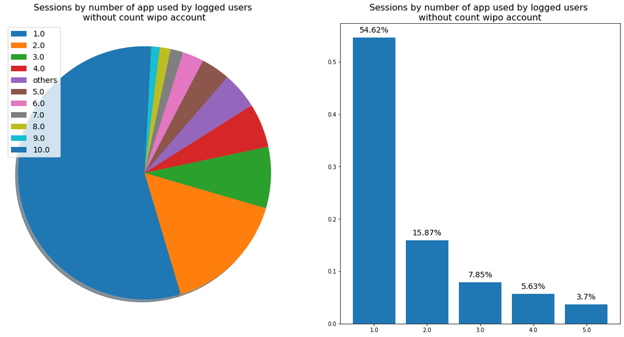

```python
ses_dur_dis = df[["session_hk_c","num_apps"]].drop_duplicates()["num_apps"][(df["user_logged_treated"]==0)&(df["user_returning"]==0)]\
                    .value_counts(normalize=True)
labels,data = ses_dur_dis.index, ses_dur_dis.values
plot_distribution(labels,data,"Sessions by number of app used by not logged users that not come back",top_n_pie=3, top_n_hist=5,xlabel="",pie_legend=True)



ses_dur_dis = df[["session_hk_c","num_apps"]].drop_duplicates()["num_apps"][(df["user_logged_treated"]==0)&(df["user_returning"]==1)]\
                    .value_counts(normalize=True)
labels,data = ses_dur_dis.index, ses_dur_dis.values
plot_distribution(labels,data,"Sessions by number of app used by not logged users that come back",top_n_pie=5, top_n_hist=5,xlabel="",pie_legend=True)


ses_dur_dis = df[["session_hk_c","num_apps"]].drop_duplicates()["num_apps"][(df["user_logged_treated"]==1)]\
                    .value_counts(normalize=True)
labels,data = ses_dur_dis.index, ses_dur_dis.values
plot_distribution(labels,data,"Sessions by number of app used by logged users",top_n_pie=10, top_n_hist=5,xlabel="",pie_legend=True)


ses_dur_dis = df[["session_hk_c","num_apps_without_wipo_account"]].drop_duplicates()["num_apps_without_wipo_account"][(df["user_logged_treated"]==1)]\
                    .value_counts(normalize=True)
labels,data = ses_dur_dis.index, ses_dur_dis.values
plot_distribution(labels,data,"Sessions by number of app used by logged users \nwithout count wipo account",top_n_pie=10, top_n_hist=5,xlabel="",pie_legend=True)
```

# Session distribution by duration

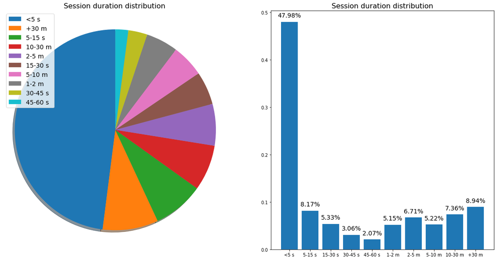

```python
ses_dur_dis = df[["session_hk_c","session_duration_range"]].drop_duplicates()["session_duration_range"]\
                    .value_counts(normalize=True)
labels,data  = sort_serie_with_duration_ranges(ses_dur_dis)
plot_distribution(labels,data,"Session duration distribution",top_n_pie=10, top_n_hist=10,xlabel="",pie_legend=True)
```

# Session distribution by duration depending on type of user

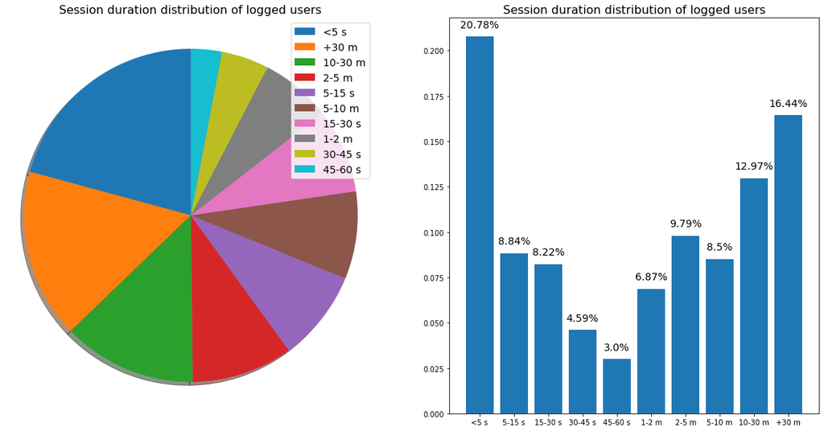

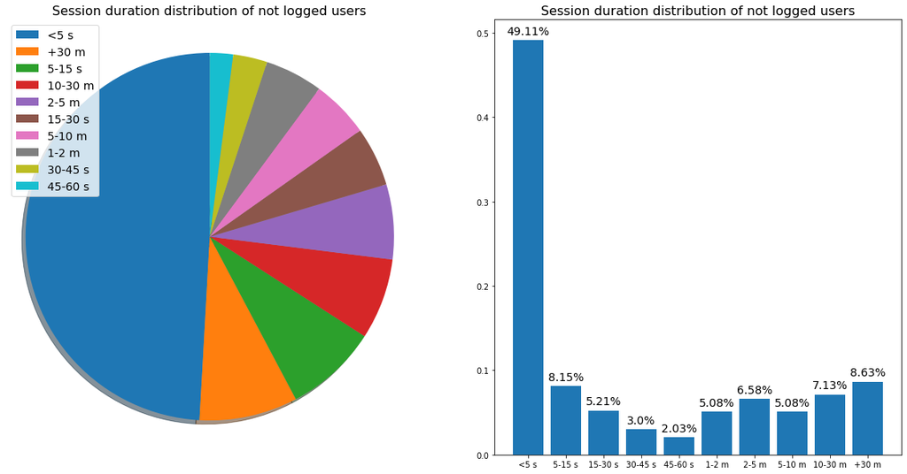

```python
ses_dur_dis = df[["session_hk_c","session_duration_range"]][df["user_logged_treated"]==1].drop_duplicates()["session_duration_range"]\
                    .value_counts(normalize=True)
labels,data  = sort_serie_with_duration_ranges(ses_dur_dis)
plot_distribution(labels,data,"Session duration distribution of logged users",top_n_pie=10, top_n_hist=10,xlabel="",pie_legend=True,bar_annot_extra=0.005)


ses_dur_dis = df[["session_hk_c","session_duration_range"]][df["user_logged_treated"]==0].drop_duplicates()["session_duration_range"]\
                    .value_counts(normalize=True)
labels,data  = sort_serie_with_duration_ranges(ses_dur_dis)
plot_distribution(labels,data,"Session duration distribution of not logged users",top_n_pie=10, top_n_hist=10,xlabel="",pie_legend=True,bar_annot_extra=0.007)
```

## Event durations before and after apply rules

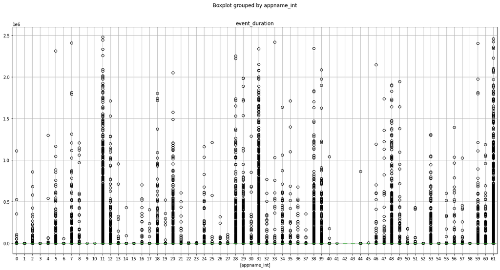

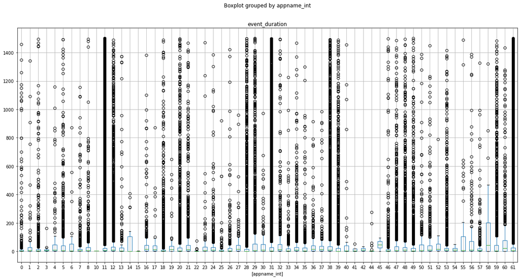

```python
boxplot = df_events.boxplot(column=['event_duration'], by=['appname_int'])
boxplot = filtered_df_events.boxplot(column=['event_duration'], by=['appname_int'])
```

## Apps durations before and after apply rules

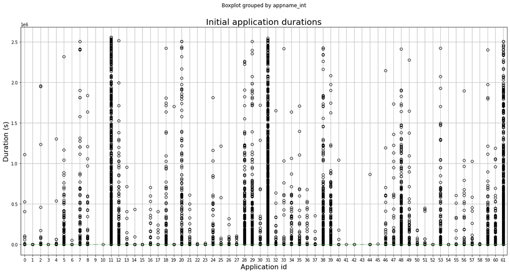

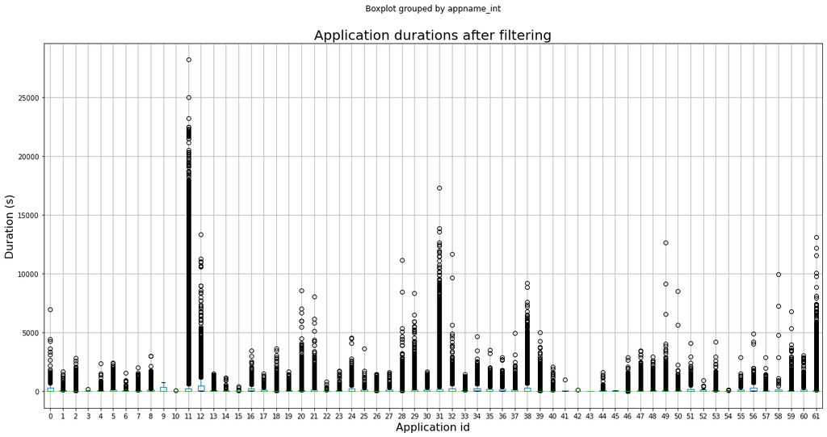

```python
boxplot = df.boxplot(column=['calculated_app_duration'], by=['appname_int'])
plt.title("Initial application durations",fontsize=20)
plt.ylabel("Duration (s)",fontsize=16)
plt.xlabel("Application id",fontsize=16)



boxplot = filtered_df.boxplot(column=['calculated_app_duration'], by=['appname_int'])
plt.title("Application durations after filtering",fontsize=20)
plt.ylabel("Duration (s)",fontsize=16)
plt.xlabel("Application id",fontsize=16)
```

## Applications mean/median durations

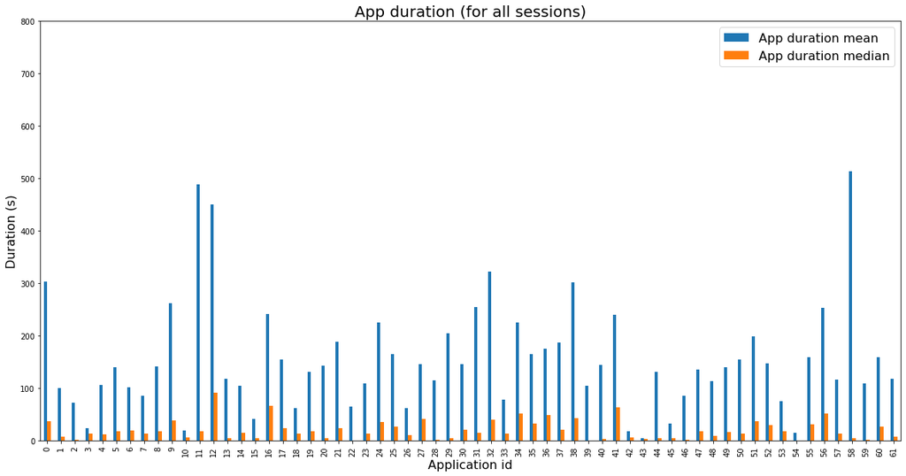

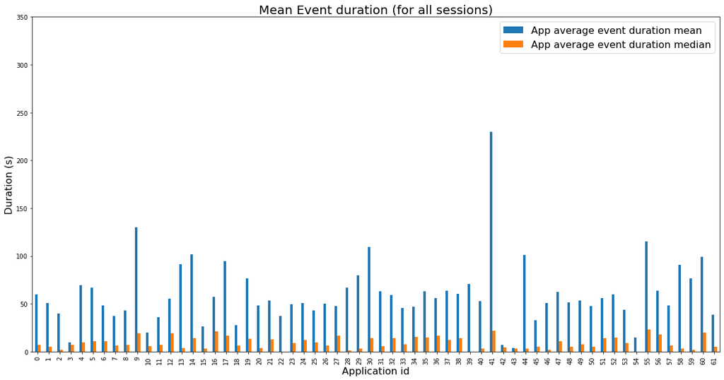

```python
aux = filtered_df[["appname_int","calculated_app_duration","app_mean_event_duration"]]\
                .groupby("appname_int").agg(["mean","median",pd.Series.mode])


aux.plot( y=[("calculated_app_duration","mean"),("calculated_app_duration","median")], kind="bar")
plt.title("App duration (for all sessions)",fontsize=20)
plt.legend(["App duration mean", "App duration median"],fontsize=16)
plt.ylabel("Duration (s)",fontsize=16)
plt.xlabel("Application id",fontsize=16)
plt.ylim(top=800)


aux.plot( y=[("app_mean_event_duration","mean"),("app_mean_event_duration","median")], kind="bar")
plt.legend(["App average event duration mean", "App average event duration median"],fontsize=16)
plt.ylim(top=350)
plt.ylabel("Duration (s)",fontsize=16)
plt.xlabel("Application id",fontsize=16)
plt.title("Mean Event duration (for all sessions)",fontsize=20)
```

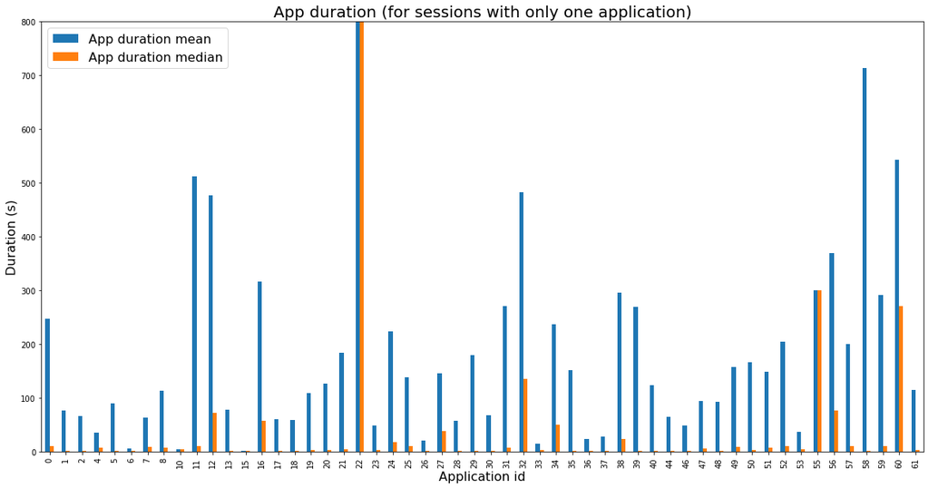

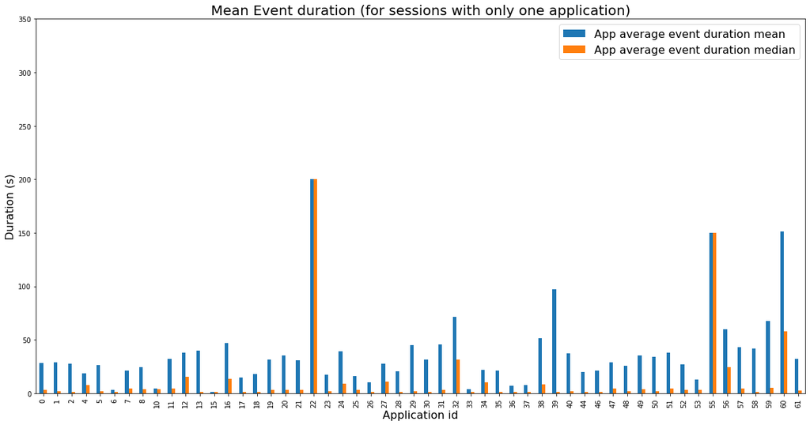

```python
aux = filtered_df[["appname_int","calculated_app_duration","app_mean_event_duration"]]\
                [filtered_df["num_apps"]==1]\
                .groupby("appname_int").agg(["mean","median",pd.Series.mode])


aux.plot( y=[("calculated_app_duration","mean"),("calculated_app_duration","median")], kind="bar")
plt.title("App duration (for sessions with only one application)",fontsize=20)
plt.legend(["App duration mean", "App duration median"],fontsize=16)
plt.ylabel("Duration (s)",fontsize=16)
plt.xlabel("Application id",fontsize=16)
plt.ylim(top=800)


aux.plot( y=[("app_mean_event_duration","mean"),("app_mean_event_duration","median")], kind="bar")
plt.legend(["App average event duration mean", "App average event duration median"],fontsize=16)
plt.ylim(top=350)
plt.ylabel("Duration (s)",fontsize=16)
plt.xlabel("Application id",fontsize=16)
plt.title("Mean Event duration (for sessions with only one application)",fontsize=20)
```

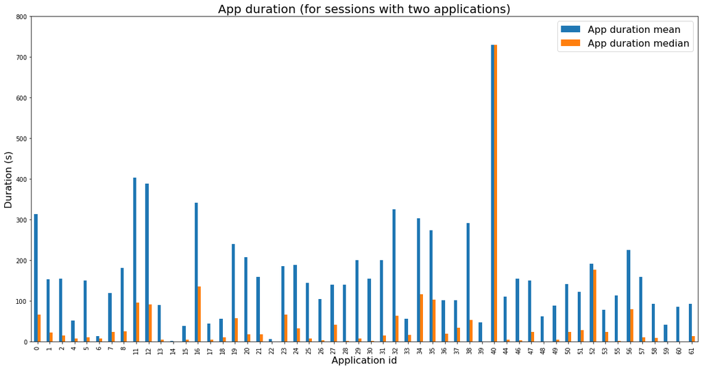

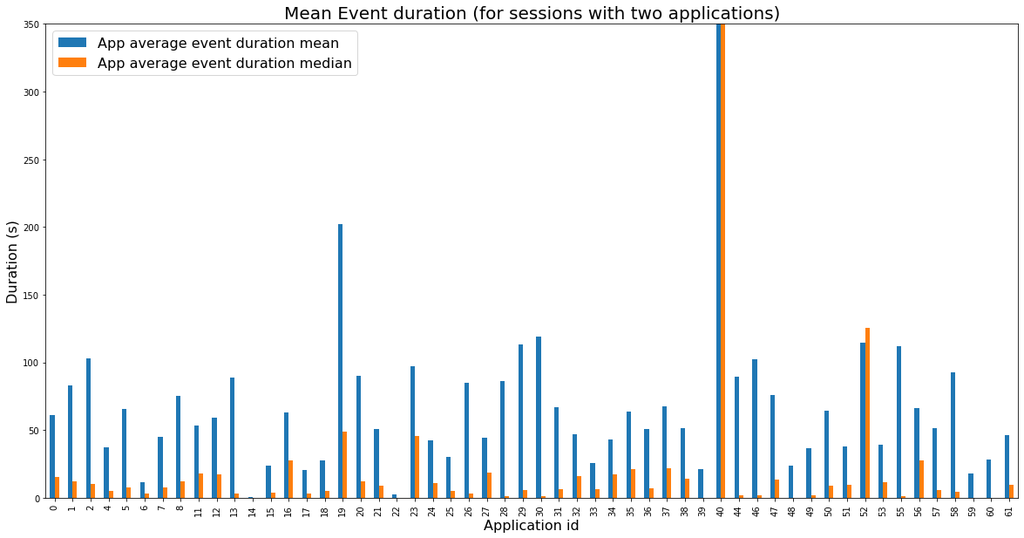

```python
aux = filtered_df[["appname_int","calculated_app_duration","app_mean_event_duration"]]\
                [filtered_df["num_apps"]==2]\
                .groupby("appname_int").agg(["mean","median"])


aux.plot( y=[("calculated_app_duration","mean"),("calculated_app_duration","median")], kind="bar")
plt.title("App duration (for sessions with two applications)",fontsize=20)
plt.legend(["App duration mean", "App duration median"],fontsize=16)
plt.ylabel("Duration (s)",fontsize=16)
plt.xlabel("Application id",fontsize=16)
plt.ylim(top=800)


aux.plot( y=[("app_mean_event_duration","mean"),("app_mean_event_duration","median")], kind="bar")
plt.legend(["App average event duration mean", "App average event duration median"],fontsize=16)
plt.ylim(top=350)
plt.ylabel("Duration (s)",fontsize=16)
plt.xlabel("Application id",fontsize=16)
plt.title("Mean Event duration (for sessions with two applications)",fontsize=20)
```

# Plots after apply rules

### Sessions distribution by apps after remove outliers and session with non human behaviour

After remove outliers, we can see that most of the sessions use only one app.

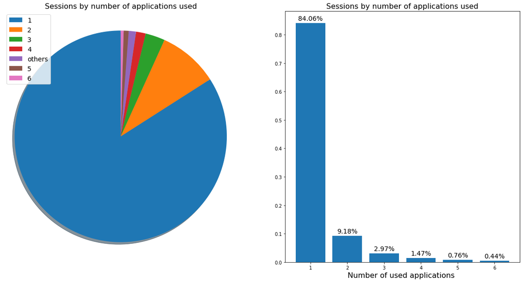

```python
ses_dur_dis = filtered_df[["session_hk_c","num_apps"]].drop_duplicates()["num_apps"]\
                    .value_counts(normalize=True)
labels,data = ses_dur_dis.index, ses_dur_dis.values
plot_distribution(labels,data,"Sessions by number of applications used",top_n_pie=6, top_n_hist=6,xlabel="Number of used applications ",pie_legend=True)
```

# SESSION DURATION DISTRIBUTION

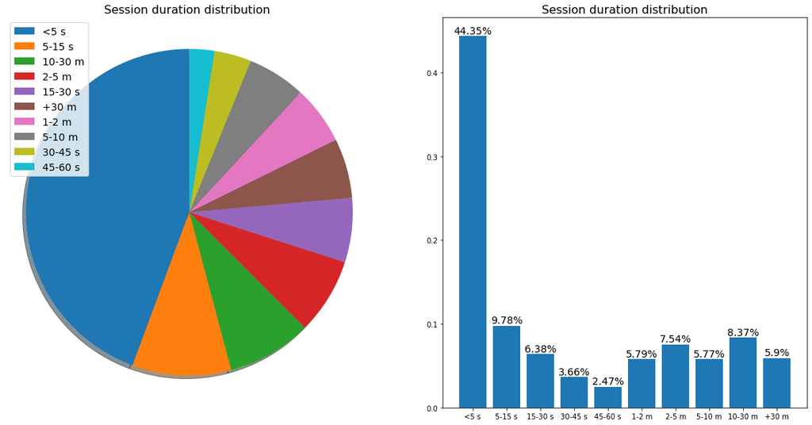

```python
ses_dur_dis = filtered_df[["session_hk_c","session_duration_range"]].drop_duplicates()["session_duration_range"]\
                    .value_counts(normalize=True)
labels,data  = sort_serie_with_duration_ranges(ses_dur_dis)
plot_distribution(labels,data,"Session duration distribution",top_n_pie=10, top_n_hist=10,xlabel="",pie_legend=True,bar_annot_extra=0.003)
```

# SESSION DISTRIBUTION BY TYPE OF USER

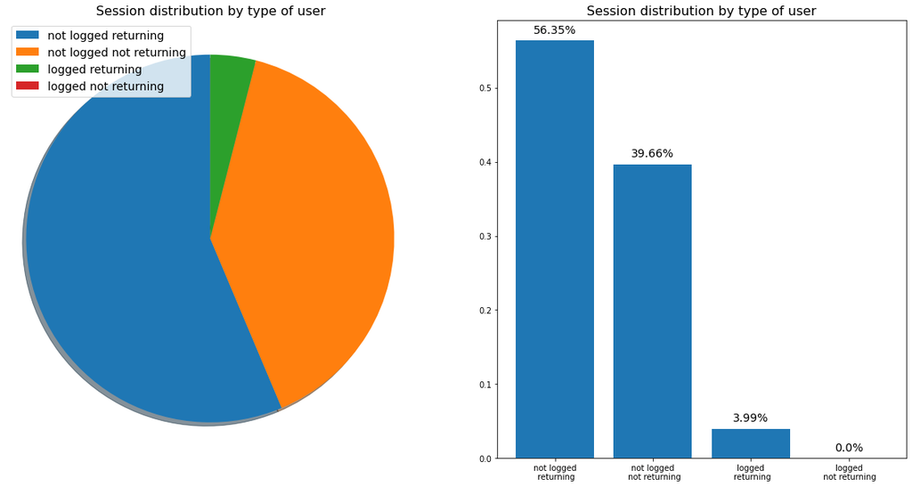

```python
user_type_dis = filtered_df[["session_hk_c","visitor_id_c","user_description"]].drop_duplicates()\
                ["user_description"].value_counts(normalize=True)
labels,data = user_type_dis.index, user_type_dis.values
plot_distribution(labels,data,"Session distribution by type of user",top_n_pie=8, top_n_hist=5,xlabel="",pie_legend=True)
```

# NUMBER OF SESSIONS BY USER

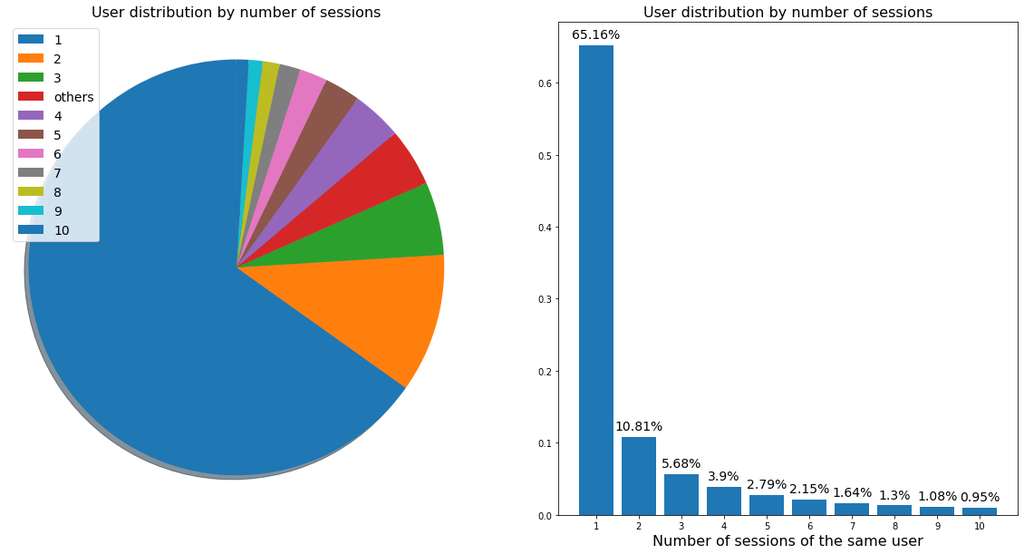

```python
user_type_dis = filtered_df[["session_hk_c","visitor_id_c","user_description"]].drop_duplicates()\
                .groupby("visitor_id_c")["visitor_id_c"].transform("count").value_counts(normalize=True)
labels,data = user_type_dis.index, user_type_dis.values
plot_distribution(labels,data,"User distribution by number of sessions",top_n_pie=10, top_n_hist=10,xlabel="Number of sessions of the same user",pie_legend=True)
```

# Applications distribution after filtering outliers depending on the number of applications used on a session

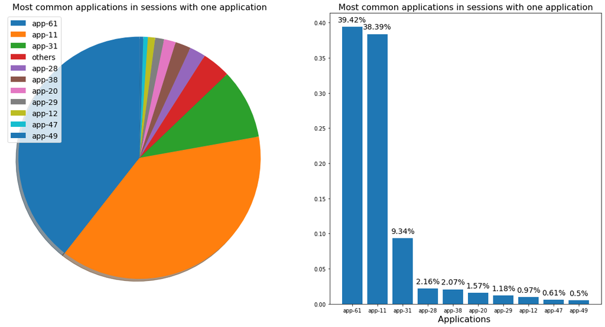

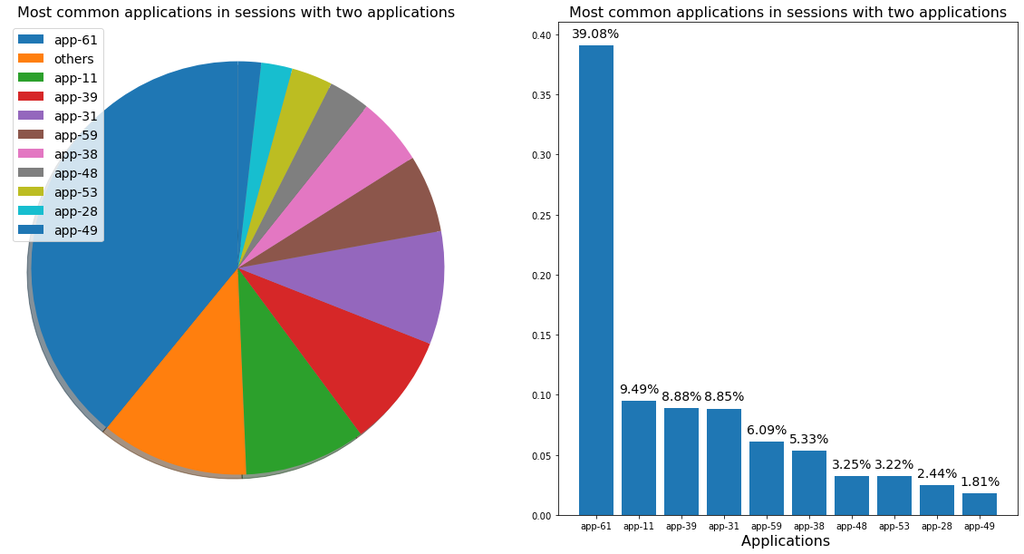

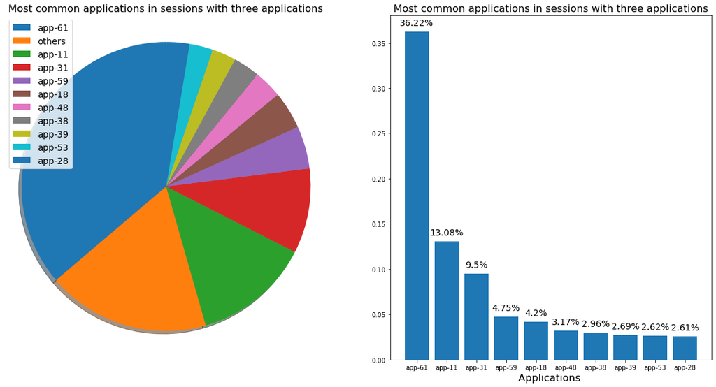

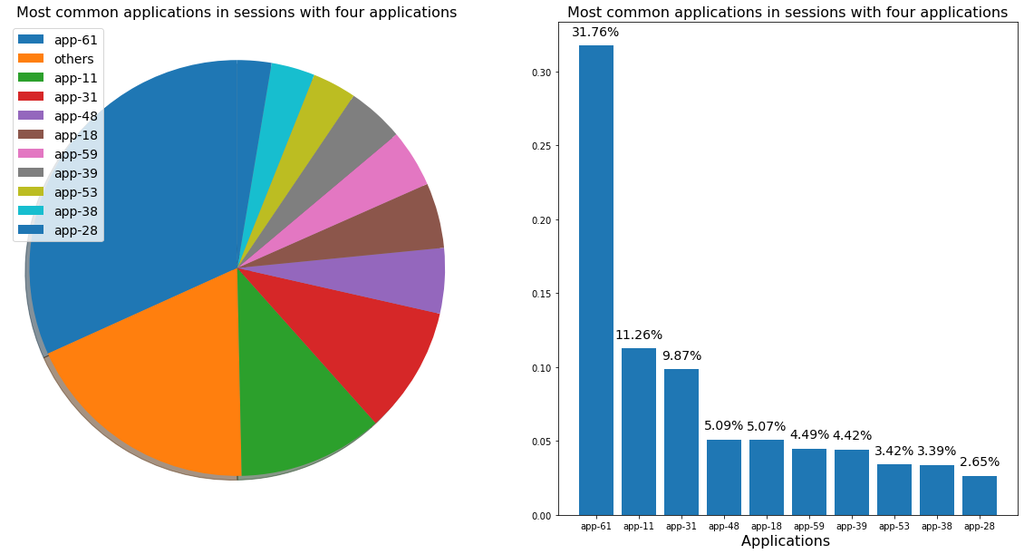

```python
app_dis = filtered_df[filtered_df["num_apps"]==1][["appname_c"]]["appname_c"].value_counts(normalize=True)
labels,data = app_dis.index, app_dis.values
plot_distribution(labels,data,"Most common applications in sessions with one application",top_n_pie=10, top_n_hist=10,xlabel="Applications ",pie_legend=True, bar_annot_extra=0.007)


app_dis = filtered_df[filtered_df["num_apps"]==2][["appname_c"]]["appname_c"].value_counts(normalize=True)
labels,data = app_dis.index, app_dis.values
plot_distribution(labels,data,"Most common applications in sessions with two applications",top_n_pie=10, top_n_hist=10,xlabel="Applications ",pie_legend=True, bar_annot_extra=0.007)


app_dis = filtered_df[filtered_df["num_apps"]==3][["appname_c"]]["appname_c"].value_counts(normalize=True)
labels,data = app_dis.index, app_dis.values
plot_distribution(labels,data,"Most common applications in sessions with three applications",top_n_pie=10, top_n_hist=10,xlabel="Applications ",pie_legend=True, bar_annot_extra=0.007)



app_dis = filtered_df[filtered_df["num_apps"]==4][["appname_c"]]["appname_c"].value_counts(normalize=True)
labels,data = app_dis.index, app_dis.values
plot_distribution(labels,data,"Most common applications in sessions with four applications",top_n_pie=10, top_n_hist=10,xlabel="Applications ",pie_legend=True,bar_annot_extra=0.007)
```